# Real Projective Spaces and 3x3 Rotation Matrices

Glenn Davis

2026-08-21

# Introduction

```r
library(polarzonoid)
```

In this vignette, we define some configuration spaces of an even number of points on the circle, and show that they are homeomorphic to real projective spaces $\mathbb{R}\text{P}^n$. Since $\mathbb{R}\text{P}^3$ is homeomorphic to the group of 3x3 rotation matrices $\text{SO(3)}$, we also have a homeomorphism with that space.

A prerequisite to understanding this vignette is the section on spaces of arcs $A_n$ in the User Guide vignette.

# Two Natural Involutions

The sphere $\mathbb{S}^{2n}$ has natural involution, the antipodal map, given by $\alpha(u) = -u$.

The space of arcs $A_n$ has a natural involution $\gamma$, which is the complementation operation, given by $\gamma(V) = \operatorname{Cl}(\mathbb{S}^1 - V)$. The closure $\operatorname{Cl}$ is only necessary to create closed arcs. Note that $\gamma()$ has the important property that it leaves the arc endpoints fixed.

It is easy to show that the homeomorphism $A_n ~ \longleftrightarrow ~ \mathbb{S}^{2n}$ conjugates these 2 involutions. We have a commutative diagram:

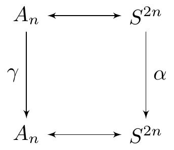

the involutions are conjugate

If we identify pairs of points for both spaces with the equivalence relation $\sim$, we get an induced homeomorphism $A_n/\sim ~ \longleftrightarrow ~ \mathbb{S}^{2n}/\sim$. The latter space is real projective space $\mathbb{R}\text{P}^{2n}$. Since $\gamma$ leaves the arc endpoints fixed, we can view a point in $A_n/\sim$ as simply the endpoints of the arcs; this is justified in the next section.

# The Space $P_{2n}$

We define $P_{2n}$ to be the configuration space of $2n$ *or fewer and even* number of points in the circle $\mathbb{S}^1$. So $P_2$ is the space of 2 points, $P_4$ is the space of 4 or 2 points, etc. We also define $P_0$ to be a single point. We have proper inclusions:
$$\begin{equation}
P_0 ~ \subset ~ P_2 ~ \subset ~ P_4 ~ \subset ~ P_6 ~ \subset
~ ...
\end{equation}$$
Given $2n$ distinct points in the circle, there are 2 sets of $n$ arcs that have these as endpoints. These 2 sets are complements of each other, which are identified under the above equivalence relation. Therefore $P_{2n}$ and $A_n / \sim$ are bijective as sets. We take the induced topology on $A_n / \sim$ and transfer it to $P_{2n}$. The important thing is that if 2 neighboring points of a configuration in $P_{2n}$ get close to each other, in the limit the point configuration converges to a configuration in $P_{2(n-1)}$ where the 2 points of the configuration “disappear”. Depending on how the arcs are selected, either the arc between the points shrinks to nothing, or the gap between two arcs shrinks to nothing and the two arcs are combined. In either case the number of arcs is reduced by 1. We saw in the previous section that there is a homeomorphism $A_n / \sim ~ \longleftrightarrow ~ \mathbb{R}\text{P}^{2n}$, and so there is a homeomorphism:
$$\begin{equation}
P_{2n} ~ \longleftrightarrow ~ \mathbb{R}\text{P}^{2n}
\end{equation}$$

**SIDE NOTE:** In particular we have $P_2 ~ \leftrightarrow ~ \mathbb{R}\text{P}^2$. There is another configuration space of 2 points on the circle which is the cartesian product of two copies modulo the permutation of the points: $(\mathbb{S}^1 \times \mathbb{S}^1) / \sim$. This is given the quotient topology, so as 2 points converge to each other they become a single point. This configuration space is a Möebius band, with boundary being those single points. If the boundary is collapsed to a point, we get $P_2 ~ \leftrightarrow ~ \mathbb{R}\text{P}^2$.

# The Spaces $A_n^\pi$ and $P_{2n}^\pi$

# A Circle of Rotations around Axis [0,0,1]

This animation start at the trivial identity matrix, which maps to the antipodal points $(0,\pm1)$. Then a circle of rotations around [0,0,1] are generated which return back to the identity again. The corresponding balanced configuration of points on the circle are plotted in blue.

```r
circle      = circle_of_rotations( c(0,0,1), count=72+1 )
webm_file   = WebMfromrotationlist( circle, index=1, vpsize=c(480,480) )
video_html  = video2html(webm_file)
```

[video not shown]

circle of rotations around axis [0,0,1]

# A Circle of Rotations around Axis [0,1,0]

This animation start at the trivial identity matrix, and then a circle of rotations around [0,1,0] are generated which return back to the identity again. The corresponding balanced configuration of points on the circle are plotted in blue.

```r
circle      = circle_of_rotations( c(0,1,0), count=72+1 )
webm_file   = WebMfromrotationlist( circle, index=2, vpsize=c(480,480) )
video_html  = video2html(webm_file)
```

[video not shown]

circle of rotations around axis [0,1,0]

# A Circle of Rotations around Axis [1,0,0]

This animation start at the trivial identity matrix, and then a circle of rotations around [1,0,0] are generated which return back to the identity again. The corresponding balanced configuration of points on the circle are plotted in blue.

```r
circle      = circle_of_rotations( c(1,0,0), count=72+1 )
webm_file   = WebMfromrotationlist( circle, index=3, vpsize=c(480,480) )
video_html  = video2html(webm_file)
```

[video not shown]

circle of rotations around axis [1,0,0]

This case is different. There are only 2 antipodal points, and all these balanced point configurations are in $P_2^\pi \subset P_4^\pi$.

# A Circle of Rotations around a Random Axis

This animation start at the trivial identity matrix, and then a random axis is generated, and then a loop of rotations around that axis is generated which return back to the identity again. The corresponding balanced configuration of points on the circle are plotted in blue.

```r
set.seed(0)
axis        = rnorm(3)
axis        = axis / sqrt( sum(axis^2) )
circle      = circle_of_rotations( axis, count=72+1 )
webm_file   = WebMfromrotationlist( circle, index=4, vpsize=c(480,480) )
video_html  = video2html(webm_file)
```

[video not shown]

circle of rotations around a random axis

# References

[1]

BOTT, R. On the third symmetric potency of S1. *Fundamenta Mathematicae* [online]. 1952, **39**(1), 264–268. Available at: https://eudml.org/doc/213268

# Session Information